# Homework 06: Data wrangling wrap up

# 1 Loading libraries

First, we load the necessary libraries required for the exercises in this assignment:

```r
suppressPackageStartupMessages(library(tidyverse))
```

```r
library(stringr)
library(repurrrsive)
library(gapminder)
library(ggplot2)
library(readr)
```

# 2 Writing functions

In this exercise, we learn how to write a function in R. We shall be using the Gapminder data set for this exercise.

## 2.1 Linear regression:

We first write a function that accepts a country name in the `gapminder` data set as input and fits linear regression model to its `gdpPercap` over the years. The input is specified as a string.

```r
# function that fits a linear regression to the gdpPercap of a specified country over and  plot the result

linear_fit <- function(c_name){
   Extract_data <- gapminder %>%
          filter(country==c_name)
  mini_df <- Extract_data # calls the function that extracts the data for the specified country
  fit <- lm(gdpPercap ~ year, mini_df) # fits the linear regression

  # ggplot of result
  plt <- ggplot(mini_df,aes(year,gdpPercap)) +
      geom_point() + geom_smooth(method ="lm", se = FALSE) +
      ggtitle(str_c("GDP per cap. for ",c_name," over the years with a linear regression line "))

 coeff <- coef(fit)
 plt
  return(list(coeff,plt)) # returns the outputs as a list
  }
```

Let us test our function by calling it with some country;

```r
# testing the linear_fit function
result1 <- linear_fit("Canada")
result1[1] # displays the coefficients of the fit
```

```
## [[1]]
##  (Intercept)         year
## -871241.1081     451.4533
```

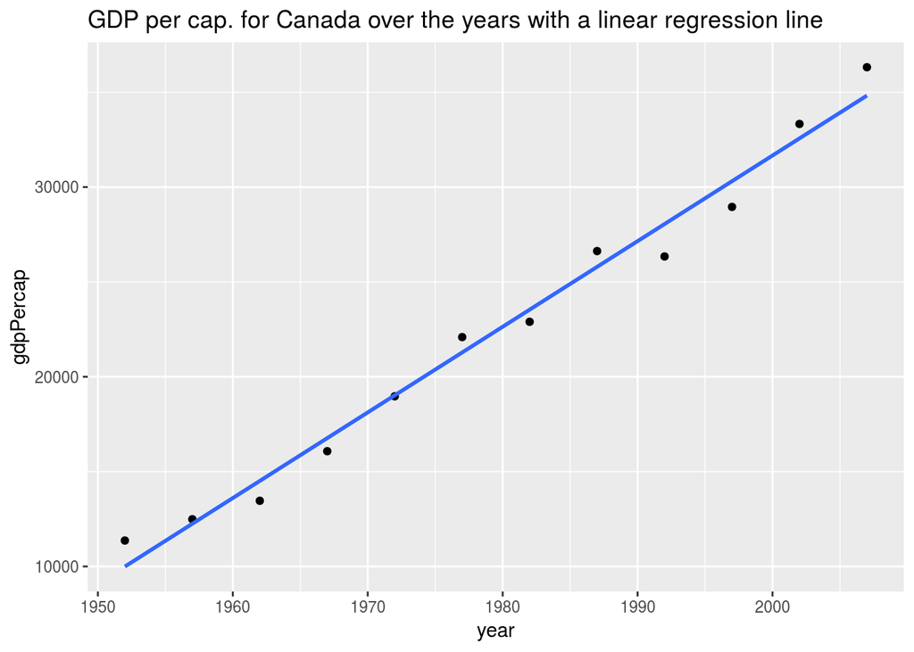

```r
result1[2] # plots the result
```

How about another country;

```r
# testing the linear_fit function
result2 <- linear_fit("Ghana")
result2[1] # displays the coefficients of the fit
```

```
## [[1]]
##  (Intercept)         year
## -1429.960073     1.250084
```

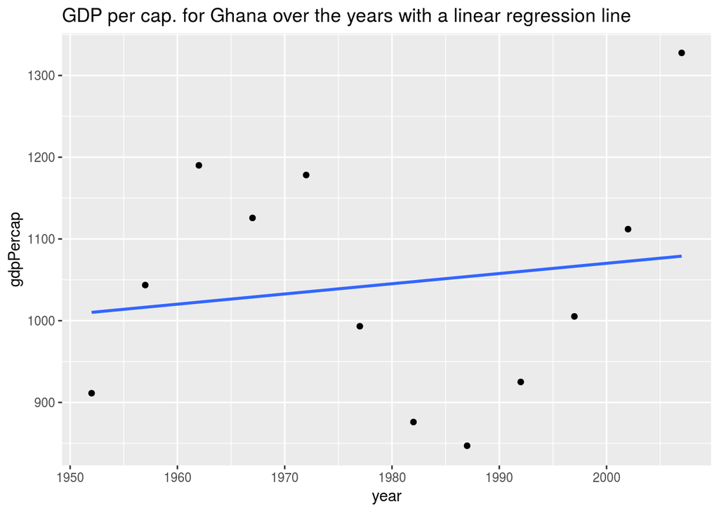

```r
result2[2] # plots the result
```

## 2.2 Multiple linear regression

Here, we write a function that fits multiple linear regression to data from gapminder data set. The function accept the country name as input (as a string) and fits a multiple linear regression to the `gdpPercap`, `pop`, and `lifeExp` in the form `gdpPercap = intercept + lifeExp*x1 + pop*x2`. The output of the function is the coefficients of the fit.

```r
Multi_linear_fit <- function(c_name){
  Extract_data <- gapminder %>%
          filter(country==c_name)
  mini_df <- Extract_data # calls the function that extracts the data for the specified country
  fit <- lm(gdpPercap ~ lifeExp + pop, mini_df) # fits the linear regression

 coef(fit)
}
```

Now, let us test our function;

```r
# testing the Multi_linear_fit function
Multi_linear_fit("Canada")
```

```
##   (Intercept)       lifeExp           pop
## -6.069152e+04  8.476864e+02  8.015472e-04
```

A second test;

```r
# testing the  Multi_linear_fit function
Multi_linear_fit("Ghana")
```

```
##   (Intercept)       lifeExp           pop
##  2.936761e+03 -4.902970e+01  5.342695e-05
```

The `Multi_linear_fit` function returns the coefficients of the fit.

## 2.3 Quadratic fit

Next, we write a function that fits a quadratic functiont to a data set. This function accepts a country name as a string from the list of country in the gapminder data set and fit a quadractic curve to the `gdpPercap` with respect to `lifeExp`. Here, the independent variable is `lifeExp` while `gdpPercap` is the dependent variable. The function returns the coefficient of the fit.

```r
Quadratic_fit <- function(c_name){
  Extract_data <- gapminder %>%
          filter(country==c_name)
  mini_df <- Extract_data # calls the function that extracts the data for the specified country
  fit <- lm(gdpPercap ~ lifeExp + I(lifeExp^2), mini_df) # fits the Quadratic regression

 coef(fit)
}
```

Let us test our function;

```r
# testing the function
Quadratic_fit("Canada")
```

```
##  (Intercept)      lifeExp I(lifeExp^2)
## 184428.34326  -6408.00963     56.52877
```

We perform a second test with Nigeria.

```r
# testing the function
Quadratic_fit("Nigeria")
```

```
##  (Intercept)      lifeExp I(lifeExp^2)
##  -8466.53882    406.88560     -4.06329
```

# 3 Work with the Candy data

In this exercise, we shall practice basic data ingest, exploration, character data cleanup, and wrangling. The data to be explored is collected from `Halloween candy survey`.

## 3.1 Loading the data set

```r
# reading the data from file
HallCandy_raw <- read_csv("CANDY-HIERARCHY-2015 SURVEY-Responses.csv",
                col_types = cols(
                  Timestamp = col_datetime("%m/%d/%Y %H:%M:%S")
                ))
```

## 3.2 Exploring the structure and properties of the data set

We begin by checking the structure of the data set

```r
str(HallCandy_raw) %>%
      head()
```

```
## Classes 'tbl_df', 'tbl' and 'data.frame':    5658 obs. of  124 variables:
##  $ Timestamp                                                                                                        : POSIXct, format: "2015-10-23 08:46:20" "2015-10-23 08:46:52" ...
##  $ How old are you?                                                                                                 : chr  "35" "41" "33" "31" ...
##  $ Are you going actually going trick or treating yourself?                                                         : chr  "No" "No" "No" "No" ...
##  $ [Butterfinger]                                                                                                   : chr  "JOY" "JOY" "DESPAIR" "JOY" ...
##  $ [100 Grand Bar]                                                                                                  : chr  NA "JOY" "DESPAIR" "JOY" ...
##  $ [Anonymous brown globs that come in black and orange wrappers]                                                   : chr  "DESPAIR" "DESPAIR" "DESPAIR" "DESPAIR" ...
##  $ [Any full-sized candy bar]                                                                                       : chr  "JOY" "JOY" "JOY" "JOY" ...
##  $ [Black Jacks]                                                                                                    : chr  NA "DESPAIR" "DESPAIR" "DESPAIR" ...
##  $ [Bonkers]                                                                                                        : chr  NA "DESPAIR" "DESPAIR" "DESPAIR" ...
##  $ [Bottle Caps]                                                                                                    : chr  NA "JOY" "DESPAIR" "JOY" ...
##  $ [Box’o’ Raisins]                                                                                                 : chr  NA "DESPAIR" "JOY" "DESPAIR" ...
##  $ [Brach products (not including candy corn)]                                                                      : chr  "DESPAIR" "DESPAIR" "DESPAIR" "DESPAIR" ...
##  $ [Bubble Gum]                                                                                                     : chr  "DESPAIR" "DESPAIR" "DESPAIR" "DESPAIR" ...
##  $ [Cadbury Creme Eggs]                                                                                             : chr  "DESPAIR" "DESPAIR" "JOY" "DESPAIR" ...
##  $ [Candy Corn]                                                                                                     : chr  NA "DESPAIR" "JOY" "DESPAIR" ...
##  $ [Vials of pure high fructose corn syrup, for main-lining into your vein]                                         : chr  "DESPAIR" "DESPAIR" "DESPAIR" "DESPAIR" ...
##  $ [Candy that is clearly just the stuff given out for free at restaurants]                                         : chr  "DESPAIR" "DESPAIR" "DESPAIR" "DESPAIR" ...
##  $ [Cash, or other forms of legal tender]                                                                           : chr  "JOY" "JOY" "JOY" "JOY" ...
##  $ [Chiclets]                                                                                                       : chr  NA "DESPAIR" "DESPAIR" "DESPAIR" ...
##  $ [Caramellos]                                                                                                     : chr  NA "DESPAIR" "JOY" "JOY" ...
##  $ [Snickers]                                                                                                       : chr  "JOY" "JOY" "JOY" "JOY" ...
##  $ [Dark Chocolate Hershey]                                                                                         : chr  "JOY" "DESPAIR" "JOY" "JOY" ...
##  $ [Dental paraphenalia]                                                                                            : chr  "DESPAIR" "DESPAIR" "DESPAIR" "DESPAIR" ...
##  $ [Dots]                                                                                                           : chr  "JOY" "JOY" "DESPAIR" "DESPAIR" ...
##  $ [Fuzzy Peaches]                                                                                                  : chr  "DESPAIR" "DESPAIR" "DESPAIR" "DESPAIR" ...
```

[output cut: 280 more lines]

It is a data frame with 5658 observations of 124 variables. Next, we look at the type

```r
typeof(HallCandy_raw)
```

```
## [1] "list"
```

This says it is a list, we know that a data frame is a type of list.

Now, let us take a look at the first few rows of the data set.

```r
HallCandy_raw %>%
  head()
```

```
## # A tibble: 6 x 124
##   Timestamp           `How old are yo… `Are you going … `[Butterfinger]`
##   <dttm>              <chr>            <chr>            <chr>
## 1 2015-10-23 08:46:20 35               No               JOY
## 2 2015-10-23 08:46:52 41               No               JOY
## 3 2015-10-23 08:47:34 33               No               DESPAIR
## 4 2015-10-23 08:47:59 31               No               JOY
## 5 2015-10-23 08:48:12 30               No               <NA>
## 6 2015-10-23 08:49:07 38               No               JOY
## # ... with 120 more variables: `[100 Grand Bar]` <chr>, `[Anonymous brown
## #   globs that come in black and orange wrappers]` <chr>, `[Any full-sized
## #   candy bar]` <chr>, `[Black Jacks]` <chr>, `[Bonkers]` <chr>, `[Bottle
## #   Caps]` <chr>, `[Box’o’ Raisins]` <chr>, `[Brach products (not
## #   including candy corn)]` <chr>, `[Bubble Gum]` <chr>, `[Cadbury Creme
## #   Eggs]` <chr>, `[Candy Corn]` <chr>, `[Vials of pure high fructose corn
## #   syrup, for main-lining into your vein]` <chr>, `[Candy that is clearly
## #   just the stuff given out for free at restaurants]` <chr>, `[Cash, or
## #   other forms of legal tender]` <chr>, `[Chiclets]` <chr>,
## #   `[Caramellos]` <chr>, `[Snickers]` <chr>, `[Dark Chocolate
## #   Hershey]` <chr>, `[Dental paraphenalia]` <chr>, `[Dots]` <chr>,
## #   `[Fuzzy Peaches]` <chr>, `[Generic Brand Acetaminophen]` <chr>, `[Glow
## #   sticks]` <chr>, `[Broken glow stick]` <chr>, `[Goo Goo
## #   Clusters]` <chr>, `[Good N' Plenty]` <chr>, `[Gum from baseball
## #   cards]` <chr>, `[Gummy Bears straight up]` <chr>, `[Creepy Religious
## #   comics/Chick Tracts]` <chr>, `[Healthy Fruit]` <chr>, `[Heath
## #   Bar]` <chr>, `[Hershey’s Kissables]` <chr>, `[Hershey’s Milk
## #   Chocolate]` <chr>, `[Hugs (actual physical hugs)]` <chr>, `[Jolly
## #   Rancher (bad flavor)]` <chr>, `[Jolly Ranchers (good flavor)]` <chr>,
## #   `[Kale smoothie]` <chr>, `[Kinder Happy Hippo]` <chr>, `[Kit
## #   Kat]` <chr>, `[Hard Candy]` <chr>, `[Lapel Pins]` <chr>,
## #   `[LemonHeads]` <chr>, `[Licorice]` <chr>, `[Licorice (not
## #   black)]` <chr>, `[Lindt Truffle]` <chr>, `[Lollipops]` <chr>,
## #   `[Mars]` <chr>, `[Mary Janes]` <chr>, `[Maynards]` <chr>, `[Milk
## #   Duds]` <chr>, `[LaffyTaffy]` <chr>, `[Minibags of chips]` <chr>,
## #   `[JoyJoy (Mit Iodine)]` <chr>, `[Reggie Jackson Bar]` <chr>, `[Pixy
## #   Stix]` <chr>, `[Nerds]` <chr>, `[Nestle Crunch]` <chr>,
## #   `[Now'n'Laters]` <chr>, `[Pencils]` <chr>, `[Milky Way]` <chr>,
## #   `[Reese’s Peanut Butter Cups]` <chr>, `[Tolberone something or
## #   other]` <chr>, `[Runts]` <chr>, `[Junior Mints]` <chr>, `[Senior
## #   Mints]` <chr>, `[Mint Kisses]` <chr>, `[Mint Juleps]` <chr>, `[Mint
## #   Leaves]` <chr>, `[Peanut M&M’s]` <chr>, `[Regular M&Ms]` <chr>, `[Mint
## #   M&Ms]` <chr>, `[Ribbon candy]` <chr>, `[Rolos]` <chr>,
## #   `[Skittles]` <chr>, `[Smarties (American)]` <chr>, `[Smarties
## #   (Commonwealth)]` <chr>, `[Chick-o-Sticks (we don’t know what that
## #   is)]` <chr>, `[Spotted Dick]` <chr>, `[Starburst]` <chr>, `[Swedish
## #   Fish]` <chr>, `[Sweetums]` <chr>, `[Those odd marshmallow circus
## #   peanut things]` <chr>, `[Three Musketeers]` <chr>, `[Peterson Brand
## #   Sidewalk Chalk]` <chr>, `[Peanut Butter Bars]` <chr>, `[Peanut Butter
## #   Jars]` <chr>, `[Trail Mix]` <chr>, `[Twix]` <chr>, `[Vicodin]` <chr>,
## #   `[White Bread]` <chr>, `[Whole Wheat anything]` <chr>, `[York
## #   Peppermint Patties]` <chr>, `Please leave any remarks or comments
## #   regarding your choices.` <chr>, `Please list any items not included
## #   above that give you JOY.` <chr>, `Please list any items not included
## #   above that give you DESPAIR.` <chr>, `Guess the number of mints in my
## #   hand.` <chr>, `Betty or Veronica?` <chr>, `Check all that apply: "I
## #   cried tears of sadness at the end of ____________"` <chr>, `"That
## #   dress* that went viral early this year - when I first saw it, it was
## #   ________"` <chr>, `Fill in the blank: "Taylor Swift is a force for
## #   ___________"` <chr>, …
```

Let us check the dimension of the data set.

```r
dim(HallCandy_raw)
```

```
## [1] 5658  124
```

## 3.3 Create respondent ID

Let us create an ID variable for each of the survey respondent, and rename the column titled “How old are you to age” to “age”. We then make the ID column to be the first column followed by the age column, followed by other columns.

```r
ID_HallCandy_raw <- HallCandy_raw %>%
  mutate(id = sprintf("ID%04d", row_number())) %>%  # creates a new column called id with  ID for each survey
  select(id,
         age = starts_with("How"),
         everything())  # rename How old are you to age" to age and re-arrange the columns
```

Let us view the new data frame

```r
ID_HallCandy_raw %>%
  head()
```

```
## # A tibble: 6 x 125
##   id    age   Timestamp           `Are you going … `[Butterfinger]`
##   <chr> <chr> <dttm>              <chr>            <chr>
## 1 ID00… 35    2015-10-23 08:46:20 No               JOY
## 2 ID00… 41    2015-10-23 08:46:52 No               JOY
## 3 ID00… 33    2015-10-23 08:47:34 No               DESPAIR
## 4 ID00… 31    2015-10-23 08:47:59 No               JOY
## 5 ID00… 30    2015-10-23 08:48:12 No               <NA>
## 6 ID00… 38    2015-10-23 08:49:07 No               JOY
## # ... with 120 more variables: `[100 Grand Bar]` <chr>, `[Anonymous brown
## #   globs that come in black and orange wrappers]` <chr>, `[Any full-sized
## #   candy bar]` <chr>, `[Black Jacks]` <chr>, `[Bonkers]` <chr>, `[Bottle
## #   Caps]` <chr>, `[Box’o’ Raisins]` <chr>, `[Brach products (not
## #   including candy corn)]` <chr>, `[Bubble Gum]` <chr>, `[Cadbury Creme
## #   Eggs]` <chr>, `[Candy Corn]` <chr>, `[Vials of pure high fructose corn
## #   syrup, for main-lining into your vein]` <chr>, `[Candy that is clearly
## #   just the stuff given out for free at restaurants]` <chr>, `[Cash, or
## #   other forms of legal tender]` <chr>, `[Chiclets]` <chr>,
## #   `[Caramellos]` <chr>, `[Snickers]` <chr>, `[Dark Chocolate
## #   Hershey]` <chr>, `[Dental paraphenalia]` <chr>, `[Dots]` <chr>,
## #   `[Fuzzy Peaches]` <chr>, `[Generic Brand Acetaminophen]` <chr>, `[Glow
## #   sticks]` <chr>, `[Broken glow stick]` <chr>, `[Goo Goo
## #   Clusters]` <chr>, `[Good N' Plenty]` <chr>, `[Gum from baseball
## #   cards]` <chr>, `[Gummy Bears straight up]` <chr>, `[Creepy Religious
## #   comics/Chick Tracts]` <chr>, `[Healthy Fruit]` <chr>, `[Heath
## #   Bar]` <chr>, `[Hershey’s Kissables]` <chr>, `[Hershey’s Milk
## #   Chocolate]` <chr>, `[Hugs (actual physical hugs)]` <chr>, `[Jolly
## #   Rancher (bad flavor)]` <chr>, `[Jolly Ranchers (good flavor)]` <chr>,
## #   `[Kale smoothie]` <chr>, `[Kinder Happy Hippo]` <chr>, `[Kit
## #   Kat]` <chr>, `[Hard Candy]` <chr>, `[Lapel Pins]` <chr>,
## #   `[LemonHeads]` <chr>, `[Licorice]` <chr>, `[Licorice (not
## #   black)]` <chr>, `[Lindt Truffle]` <chr>, `[Lollipops]` <chr>,
## #   `[Mars]` <chr>, `[Mary Janes]` <chr>, `[Maynards]` <chr>, `[Milk
## #   Duds]` <chr>, `[LaffyTaffy]` <chr>, `[Minibags of chips]` <chr>,
## #   `[JoyJoy (Mit Iodine)]` <chr>, `[Reggie Jackson Bar]` <chr>, `[Pixy
## #   Stix]` <chr>, `[Nerds]` <chr>, `[Nestle Crunch]` <chr>,
## #   `[Now'n'Laters]` <chr>, `[Pencils]` <chr>, `[Milky Way]` <chr>,
## #   `[Reese’s Peanut Butter Cups]` <chr>, `[Tolberone something or
## #   other]` <chr>, `[Runts]` <chr>, `[Junior Mints]` <chr>, `[Senior
## #   Mints]` <chr>, `[Mint Kisses]` <chr>, `[Mint Juleps]` <chr>, `[Mint
## #   Leaves]` <chr>, `[Peanut M&M’s]` <chr>, `[Regular M&Ms]` <chr>, `[Mint
## #   M&Ms]` <chr>, `[Ribbon candy]` <chr>, `[Rolos]` <chr>,
## #   `[Skittles]` <chr>, `[Smarties (American)]` <chr>, `[Smarties
## #   (Commonwealth)]` <chr>, `[Chick-o-Sticks (we don’t know what that
## #   is)]` <chr>, `[Spotted Dick]` <chr>, `[Starburst]` <chr>, `[Swedish
## #   Fish]` <chr>, `[Sweetums]` <chr>, `[Those odd marshmallow circus
## #   peanut things]` <chr>, `[Three Musketeers]` <chr>, `[Peterson Brand
## #   Sidewalk Chalk]` <chr>, `[Peanut Butter Bars]` <chr>, `[Peanut Butter
## #   Jars]` <chr>, `[Trail Mix]` <chr>, `[Twix]` <chr>, `[Vicodin]` <chr>,
## #   `[White Bread]` <chr>, `[Whole Wheat anything]` <chr>, `[York
## #   Peppermint Patties]` <chr>, `Please leave any remarks or comments
## #   regarding your choices.` <chr>, `Please list any items not included
## #   above that give you JOY.` <chr>, `Please list any items not included
## #   above that give you DESPAIR.` <chr>, `Guess the number of mints in my
## #   hand.` <chr>, `Betty or Veronica?` <chr>, `Check all that apply: "I
## #   cried tears of sadness at the end of ____________"` <chr>, `"That
## #   dress* that went viral early this year - when I first saw it, it was
## #   ________"` <chr>, `Fill in the blank: "Taylor Swift is a force for
## #   ___________"` <chr>, …
```

We see that the first column is `ID` and the column containing ages has been renamed.

## 3.4 Cleaning the `age` column

Let us clean the `age` column by removing any entry with age of length more than 2 or NA.

```r
# create a temporary column the contains the length of each entry in `age`
Temp_Col <- ID_HallCandy_raw %>%
  mutate(age_nchar = str_length(age))  # make a new column with the length of the ages
```

Let us plot a barchart of `Temp_Col` so that we can see the distribution of the lenght of the ages entered.

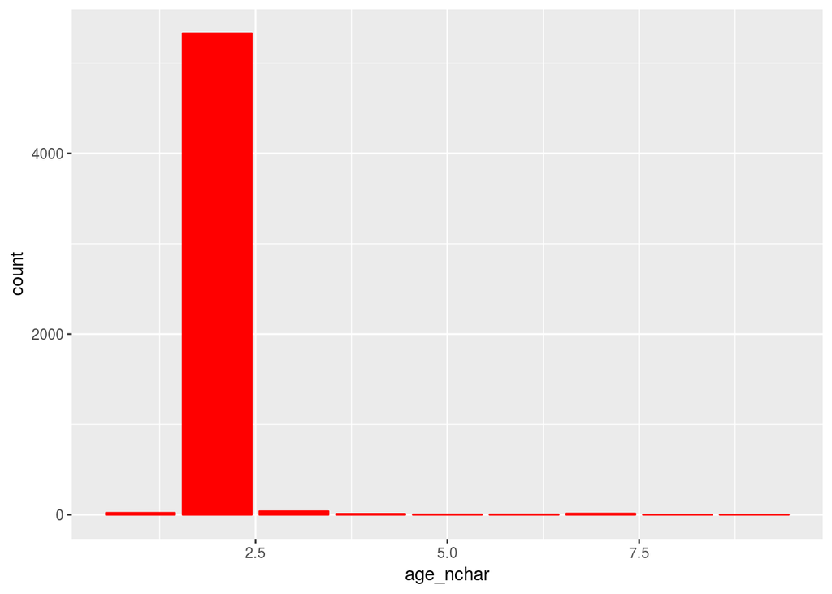

```r
Temp_Col %>%
  filter(age_nchar < 10) %>%  # extract data that have age_nchar > 10
  ggplot(aes(age_nchar)) + geom_bar(color='red', fill='red')
```

We see from this barchart that most of the entries in the `age` column have length 2 except for a few exceptions. Our goal is to remove all those data and those with `NA`.

```r
# this code removes age with length > 2
ID_HallCandy_raw <- Temp_Col %>%
        filter(age_nchar <= 2) %>%
        select(-age_nchar) %>%
        mutate(age = as.integer(age)) %>%
        filter(!is.na(age))
```

Let us check if there are still age that have length longer than 2 or is NA.

```r
ID_HallCandy_raw %>%
  select(age) %>%
  mutate(age_nchar = str_length(age)) %>%
  filter(age_nchar > 2 | age_nchar == NA)
```

```
## # A tibble: 0 x 2
## # ... with 2 variables: age <int>, age_nchar <int>
```

This shows that there is no `age` with length more than two characters and `NA`. Let see the dimension of the new data set after cleaning the `age` column.

```r
dim(ID_HallCandy_raw)  # original dim of data 5658  124
```

```
## [1] 5351  125
```

Recall that the original number of observations is 5658. The new data set has 5351 row, which means 307 rows have been removed.

## 3.5 Cleaning `candy names` column

Next we clean the column that contains `candy names`. To do this, we shall remove those `[` from the candy names. We begin by creating a new data frame with 4 columns. These columns are as follows;

1. candy names as in the original data set
2. Determine if it is a candy name or not. If the variable name is in `[]`, it is considered a candy name.
3. The new candy name, which is just the old name without the brackets `[]`
4. It indicates if the name was changed or not

```r
Temp_names <-  data_frame(orig_name = names(ID_HallCandy_raw)) %>%
                mutate(is_candy = str_detect(orig_name,"^\\["),             #
                new_name = str_replace_all(orig_name, "(^\\[)(.*)(\\]$)", "\\2"),
                new_name = str_replace_all(new_name, '["’]', "'"),
                is_changed = orig_name != new_name)
```

Let us take a look at the data frame.

```r
Temp_names %>%
  head() %>%
  knitr::kable()
```

| orig_name | is_candy | new_name | is_changed |
| --- | --- | --- | --- |
| id | FALSE | id | FALSE |
| age | FALSE | age | FALSE |
| Timestamp | FALSE | Timestamp | FALSE |
| Are you going actually going trick or treating yourself? | FALSE | Are you going actually going trick or treating yourself? | FALSE |
| [Butterfinger] | TRUE | Butterfinger | TRUE |
| [100 Grand Bar] | TRUE | 100 Grand Bar | TRUE |

How many of the varibales are candy names?

```r
sum(Temp_names$is_candy)  # counts those rows that have candy names
```

```
## [1] 95
```

Now, we replace the original names in the data set with the new names.

```r
names(ID_HallCandy_raw) <- Temp_names$new_name  # replace the  names in Halloween data frame with the cleaned names
```

## 3.6 Write `ID` and candy variables to file

Next, we shall write id and the candy variables out to file.

```r
# extract the variables that are candy names
candy_names <- Temp_names %>%
  filter(is_candy) %>%  # extract names with is_candy = TRUE and pipes it into the next line
  .$new_name
length(candy_names)
```

```
## [1] 95
```

This shows that 95 of our varibales names are candy names. We shall the candy names and write them to a file together with thier id.

```r
candy_data_untidy <- ID_HallCandy_raw %>%
  select(one_of(c("id", candy_names)))

write_csv(candy_data_untidy, "candy-joy-untidy.csv")
```

## 3.7 Write other variables to file

We shall create a table of some selective variable that are not candy names and write them into a file. First, let us extract those variables from the `ID_HallCandy_raw` data frame, and call the new data frame `NotCandy_data`.

```r
NotCandy_data <- ID_HallCandy_raw %>%
  select(-one_of(candy_names))

NotCandy_data  %>%
  head()
```

```
## # A tibble: 6 x 30
##   id      age Timestamp           `Are you going … `Please leave a…
##   <chr> <int> <dttm>              <chr>            <chr>
## 1 ID00…    35 2015-10-23 08:46:20 No               <NA>
## 2 ID00…    41 2015-10-23 08:46:52 No               <NA>
## 3 ID00…    33 2015-10-23 08:47:34 No               <NA>
## 4 ID00…    31 2015-10-23 08:47:59 No               <NA>
## 5 ID00…    30 2015-10-23 08:48:12 No               <NA>
## 6 ID00…    38 2015-10-23 08:49:07 No               <NA>
## # ... with 25 more variables: `Please list any items not included above
## #   that give you JOY.` <chr>, `Please list any items not included above
## #   that give you DESPAIR.` <chr>, `Guess the number of mints in my
## #   hand.` <chr>, `Betty or Veronica?` <chr>, `Check all that apply: 'I
## #   cried tears of sadness at the end of ____________'` <chr>, `'That
## #   dress* that went viral early this year - when I first saw it, it was
## #   ________'` <chr>, `Fill in the blank: 'Taylor Swift is a force for
## #   ___________'` <chr>, `What is your favourite font?` <chr>, `If you
## #   squint really hard, the words 'Intelligent Design' would look
## #   like.` <chr>, `Fill in the blank: 'Imitation is a form of
## #   ____________'` <chr>, `Please estimate the degree(s) of separation you
## #   have from the following celebrities [JK Rowling]` <chr>, `Please
## #   estimate the degree(s) of separation you have from the following
## #   celebrities [JJ Abrams]` <chr>, `Please estimate the degree(s) of
## #   separation you have from the following celebrities [Beyoncé]` <chr>,
## #   `Please estimate the degree(s) of separation you have from the
## #   following celebrities [Bieber]` <chr>, `Please estimate the degree(s)
## #   of separation you have from the following celebrities [Kevin
## #   Bacon]` <chr>, `Please estimate the degree(s) of separation you have
## #   from the following celebrities [Francis Bacon (1561 - 1626)]` <chr>,
## #   `Which day do you prefer, Friday or Sunday?` <chr>, `Please estimate
## #   the degrees of separation you have from the following folks [Bruce
## #   Lee]` <chr>, `Please estimate the degrees of separation you have from
## #   the following folks [JK Rowling]` <chr>, `Please estimate the degrees
## #   of separation you have from the following folks [Malala
## #   Yousafzai]` <chr>, `Please estimate the degrees of separation you have
## #   from the following folks [Thom Yorke]` <chr>, `Please estimate the
## #   degrees of separation you have from the following folks [JJ
## #   Abrams]` <chr>, `Please estimate the degrees of separation you have
## #   from the following folks [Hillary Clinton]` <chr>, `Please estimate
## #   the degrees of separation you have from the following folks [Donald
## #   Trump]` <chr>, `Please estimate the degrees of separation you have
## #   from the following folks [Beyoncé Knowles]` <chr>
```

Let us check the variable names in this data frame

```r
names(NotCandy_data) %>%
  head()
```

```
## [1] "id"
## [2] "age"
## [3] "Timestamp"
## [4] "Are you going actually going trick or treating yourself?"
## [5] "Please leave any remarks or comments regarding your choices."
## [6] "Please list any items not included above that give you JOY."
```

```r
NamesDF  <- data_frame(
  orig_name = c(
    "id",
    "age",
    "Timestamp",
    "Are you going actually going trick or treating yourself?",
    "Guess the number of mints in my hand.",
    "'That dress* that went viral early this year - when I first saw it, it was ________'",
    "What is your favourite font?"),
  new_name = c(
    "id",
    "age",
    "timestamp",
    "trick_or_treat",
    "n_mints",
    "dress",
    "font")
)


NamesDF %>%
  knitr::kable()
```

| orig_name | new_name |
| --- | --- |
| id | id |
| age | age |
| Timestamp | timestamp |
| Are you going actually going trick or treating yourself? | trick_or_treat |
| Guess the number of mints in my hand. | n_mints |
| ‘That dress* that went viral early this year - when I first saw it, it was ________’ | dress |
| What is your favourite font? | font |

Now, we extract the columns containing the names we want to change

```r
NotCandy_data <- NotCandy_data %>%
  select(one_of(NamesDF$orig_name))
NotCandy_data
```

```
## # A tibble: 5,351 x 7
##    id      age Timestamp           `Are you going … `Guess the numb…
##    <chr> <int> <dttm>              <chr>            <chr>
##  1 ID00…    35 2015-10-23 08:46:20 No               2
##  2 ID00…    41 2015-10-23 08:46:52 No               10
##  3 ID00…    33 2015-10-23 08:47:34 No               4
##  4 ID00…    31 2015-10-23 08:47:59 No               5
##  5 ID00…    30 2015-10-23 08:48:12 No               0
##  6 ID00…    38 2015-10-23 08:49:07 No               2
##  7 ID00…    48 2015-10-23 08:50:09 No               0
##  8 ID00…    39 2015-10-23 08:52:14 No               12
##  9 ID00…    54 2015-10-23 08:53:31 No               7
## 10 ID00…    40 2015-10-23 08:54:15 No               4
## # ... with 5,341 more rows, and 2 more variables: `'That dress* that went
## #   viral early this year - when I first saw it, it was ________'` <chr>,
## #   `What is your favourite font?` <chr>
```

Let us delete the variable names in the `NotCandy_data` except the ones that matches the names in `orig_name`

```r
MatchResult <- match(NamesDF$orig_name, names(NotCandy_data))  # finds the names that matches
names(NotCandy_data) <- NamesDF$new_name[MatchResult]   # replace the variable names in ID_data with new names
NotCandy_data
```

```
## # A tibble: 5,351 x 7
##    id       age timestamp           trick_or_treat n_mints dress   font
##    <chr>  <int> <dttm>              <chr>          <chr>   <chr>   <chr>
##  1 ID0001    35 2015-10-23 08:46:20 No             2       White … fuck y…
##  2 ID0002    41 2015-10-23 08:46:52 No             10      Blue a… arial
##  3 ID0003    33 2015-10-23 08:47:34 No             4       Blue a… Proggy…
##  4 ID0004    31 2015-10-23 08:47:59 No             5       White … georgia
##  5 ID0005    30 2015-10-23 08:48:12 No             0       White … verdana
##  6 ID0006    38 2015-10-23 08:49:07 No             2       Blue a… Calibri
##  7 ID0007    48 2015-10-23 08:50:09 No             0       Blue a… centur…
##  8 ID0008    39 2015-10-23 08:52:14 No             12      Blue a… winddi…
##  9 ID0010    54 2015-10-23 08:53:31 No             7       Blue a… Comic …
## 10 ID0011    40 2015-10-23 08:54:15 No             4       White … Calibri
## # ... with 5,341 more rows
```

We can also write this data frame into a file as follows

```r
write_csv(NotCandy_data, "candy-id.csv")
```

## 3.8 Tidy the candy data

Finally, we tidy the candy data. We shall gather the data and check which of them has `JOY` as thier entry.

```r
# tidy the data frame
candy_dat <- candy_data_untidy %>%
  gather(candy, joy,  -id) %>%  # collects variable and their values into a new data frame such that each variable is now a row
  mutate(joy = joy == "JOY")  # set TRUE for all row with value = JOY and false otherwise
```

Then write the data to file called `candy-joy.csv`.

```r
write_csv(candy_dat, "candy-joy.csv")
```

This file is too large and will not be uploaded on github.

# 4 Work with a list:

Instruction: Work through and write up a lesson from the `purrr` tutorial: [Trump Android words](https://jennybc.github.io/purrr-tutorial/ls08_trump-tweets.html)

Let’s first load the required for this exercise.

```r
library(purrr)
```

## 4.1 Loading the data set

Now, let us load the data set `trump_tweets_df.rda` from file.

```r
load("trump_tweets_df.rda") # loads data set
```

We check some properties of the data set.

```r
typeof(trump_tweets_df)
```

```
## [1] "list"
```

```r
glimpse(trump_tweets_df)
```

```
## Observations: 1,512
## Variables: 16
## $ text          <chr> "My economic policy speech will be carried live ...
## $ favorited     <lgl> FALSE, FALSE, FALSE, FALSE, FALSE, FALSE, FALSE,...
## $ favoriteCount <dbl> 9214, 6981, 15724, 19837, 34051, 29831, 19223, 1...
## $ replyToSN     <chr> NA, NA, NA, NA, NA, NA, NA, NA, NA, NA, NA, NA, ...
## $ created       <dttm> 2016-08-08 15:20:44, 2016-08-08 13:28:20, 2016-...
## $ truncated     <lgl> FALSE, FALSE, FALSE, FALSE, FALSE, FALSE, FALSE,...
## $ replyToSID    <lgl> NA, NA, NA, NA, NA, NA, NA, NA, NA, NA, NA, NA, ...
## $ id            <chr> "762669882571980801", "762641595439190016", "762...
## $ replyToUID    <chr> NA, NA, NA, NA, NA, NA, NA, NA, NA, NA, NA, NA, ...
## $ statusSource  <chr> "<a href=\"http://twitter.com/download/android\"...
## $ screenName    <chr> "realDonaldTrump", "realDonaldTrump", "realDonal...
## $ retweetCount  <dbl> 3107, 2390, 6691, 6402, 11717, 9892, 5784, 7930,...
## $ isRetweet     <lgl> FALSE, FALSE, FALSE, FALSE, FALSE, FALSE, FALSE,...
## $ retweeted     <lgl> FALSE, FALSE, FALSE, FALSE, FALSE, FALSE, FALSE,...
## $ longitude     <chr> NA, NA, NA, NA, NA, NA, NA, NA, NA, NA, NA, NA, ...
## $ latitude      <chr> NA, NA, NA, NA, NA, NA, NA, NA, NA, NA, NA, NA, ...
```

```r
str(trump_tweets_df)
```

```
## Classes 'tbl_df', 'tbl' and 'data.frame':    1512 obs. of  16 variables:
##  $ text         : chr  "My economic policy speech will be carried live at 12:15 P.M. Enjoy!" "Join me in Fayetteville, North Carolina tomorrow evening at 6pm. Tickets now available at: https://t.co/Z80d4MYIg8" "#ICYMI: \"Will Media Apologize to Trump?\" https://t.co/ia7rKBmioA" "Michael Morell, t…
##  $ favorited    : logi  FALSE FALSE FALSE FALSE FALSE FALSE ...
##  $ favoriteCount: num  9214 6981 15724 19837 34051 ...
##  $ replyToSN    : chr  NA NA NA NA ...
##  $ created      : POSIXct, format: "2016-08-08 15:20:44" "2016-08-08 13:28:20" ...
##  $ truncated    : logi  FALSE FALSE FALSE FALSE FALSE FALSE ...
##  $ replyToSID   : logi  NA NA NA NA NA NA ...
##  $ id           : chr  "762669882571980801" "762641595439190016" "762439658911338496" "762425371874557952" ...
##  $ replyToUID   : chr  NA NA NA NA ...
##  $ statusSource : chr  "<a href=\"http://twitter.com/download/android\" rel=\"nofollow\">Twitter for Android</a>" "<a href=\"http://twitter.com/download/iphone\" rel=\"nofollow\">Twitter for iPhone</a>" "<a href=\"http://twitter.com/download/iphone\" rel=\"nofollow\">Twitter for iPhone</a>" "<a h…
##  $ screenName   : chr  "realDonaldTrump" "realDonaldTrump" "realDonaldTrump" "realDonaldTrump" ...
##  $ retweetCount : num  3107 2390 6691 6402 11717 ...
##  $ isRetweet    : logi  FALSE FALSE FALSE FALSE FALSE FALSE ...
##  $ retweeted    : logi  FALSE FALSE FALSE FALSE FALSE FALSE ...
##  $ longitude    : chr  NA NA NA NA ...
##  $ latitude     : chr  NA NA NA NA ...
```

```r
dim(trump_tweets_df)
```

```
## [1] 1512   16
```

The data set has 1512 rows and 16 columns. We display first 6 rows of the data

```r
trump_tweets_df %>%
  head()
```

```
## # A tibble: 6 x 16
##   text  favorited favoriteCount replyToSN created             truncated
##   <chr> <lgl>             <dbl> <chr>     <dttm>              <lgl>
## 1 My e… FALSE              9214 <NA>      2016-08-08 15:20:44 FALSE
## 2 Join… FALSE              6981 <NA>      2016-08-08 13:28:20 FALSE
## 3 "#IC… FALSE             15724 <NA>      2016-08-08 00:05:54 FALSE
## 4 Mich… FALSE             19837 <NA>      2016-08-07 23:09:08 FALSE
## 5 "The… FALSE             34051 <NA>      2016-08-07 21:31:46 FALSE
## 6 I se… FALSE             29831 <NA>      2016-08-07 13:49:29 FALSE
## # ... with 10 more variables: replyToSID <lgl>, id <chr>,
## #   replyToUID <chr>, statusSource <chr>, screenName <chr>,
## #   retweetCount <dbl>, isRetweet <lgl>, retweeted <lgl>, longitude <chr>,
## #   latitude <chr>
```

Next, extract the column called `text` from the data set and save it as `tweets. This is the data we shall be focusing on in this exercise.

```r
tweets <- trump_tweets_df$text

tweets %>%
  head() %>% # displays first 6 entries
  strtrim(70) # trim to only 70 characters (including space) per entry
```

```
## [1] "My economic policy speech will be carried live at 12:15 P.M. Enjoy!"
## [2] "Join me in Fayetteville, North Carolina tomorrow evening at 6pm. Ticke"
## [3] "#ICYMI: \"Will Media Apologize to Trump?\" https://t.co/ia7rKBmioA"
## [4] "Michael Morell, the lightweight former Acting Director of C.I.A., and "
## [5] "The media is going crazy. They totally distort so many things on purpo"
## [6] "I see where Mayor Stephanie Rawlings-Blake of Baltimore is pushing Cro"
```

## 4.2 Trump Android words

Below are some words that are known to be associated with Trump tweets from an Android device. These words are put together to form a string called `regex`.

```r
regex <- "badly|crazy|weak|spent|strong|dumb|joke|guns|funny|dead"
regex
```

```
## [1] "badly|crazy|weak|spent|strong|dumb|joke|guns|funny|dead"
```

## 4.3 Extracting trump android words

The goal of this exercise is to extract these words from the tweets stored, while practising `purrr` We begin by selecting some row from `tweets` that have the complexity we would like to explore. This is because we can easily see what is going on if we have less rows.

```r
tweets <- tweets[c(1, 2, 5, 6, 198, 347, 919)]
tweets %>%
  strtrim(70)
```

```
## [1] "My economic policy speech will be carried live at 12:15 P.M. Enjoy!"
## [2] "Join me in Fayetteville, North Carolina tomorrow evening at 6pm. Ticke"
## [3] "The media is going crazy. They totally distort so many things on purpo"
## [4] "I see where Mayor Stephanie Rawlings-Blake of Baltimore is pushing Cro"
## [5] "Bernie Sanders started off strong, but with the selection of Kaine for"
## [6] "Crooked Hillary Clinton is unfit to serve as President of the U.S. Her"
## [7] "The Cruz-Kasich pact is under great strain. This joke of a deal is fal"
```

Next, we use the base function `gregexpr()` to locate all the Trump Android words inside the tweets

```r
matches <- gregexpr(regex, tweets)
str(matches)
```

```
## List of 7
##  $ : atomic [1:1] -1
##   ..- attr(*, "match.length")= int -1
##   ..- attr(*, "useBytes")= logi TRUE
##  $ : atomic [1:1] -1
##   ..- attr(*, "match.length")= int -1
##   ..- attr(*, "useBytes")= logi TRUE
##  $ : atomic [1:1] 20
##   ..- attr(*, "match.length")= int 5
##   ..- attr(*, "useBytes")= logi TRUE
##  $ : atomic [1:1] 134
##   ..- attr(*, "match.length")= int 4
##   ..- attr(*, "useBytes")= logi TRUE
##  $ : atomic [1:2] 28 95
##   ..- attr(*, "match.length")= int [1:2] 6 4
##   ..- attr(*, "useBytes")= logi TRUE
##  $ : atomic [1:2] 87 114
##   ..- attr(*, "match.length")= int [1:2] 4 6
##   ..- attr(*, "useBytes")= logi TRUE
##  $ : atomic [1:3] 50 112 123
##   ..- attr(*, "match.length")= int [1:3] 4 4 4
##   ..- attr(*, "useBytes")= logi TRUE
```

This shows if the rows contains any of the `Trump Android word`. The information displaced by the `str()` function shows the attributes of matches for each tweet. We shall use the result for each tweet to explain the content of matches. Let us see what is contained in matches for the tweet in row 1 and row 3.

```r
matches[[1]]
```

```
## [1] -1
## attr(,"match.length")
## [1] -1
## attr(,"useBytes")
## [1] TRUE
```

```r
matches[[3]]
```

```
## [1] 20
## attr(,"match.length")
## [1] 5
## attr(,"useBytes")
## [1] TRUE
```

The first information in matches for each tweet indicates if a Trump Android word is in the tweet. If there is none of those words in the tweet, it displays `-1`, otherwise, it displace the position of the first character of each of the Android words encountered in the tweet. For instance, for the first tweet, `-1` is displayed which indicates there is no Trump android word in the tweet, while for the third tweet, `20` is displayed, this shows that there is an Andriod word in the tweet and the first character of the word is the 20th character of the tweet.

The second information provided by matches is the length of the Android word in the tweet. It displays `-1` if none of those words exist in the tweet, otherwise, it displays the length of the word. Observe in the code above, the result for the second attribute is `-1` for tweet number 1, this is because the tweet does not contain any of the Android words. On the other hand, `5` is displayde for the third tweet, which indicate the length of the Trump android word found in the tweet.

One of our goals is to extract these words from the tweets.

Let us check the length of the attributes for each tweet in matches. This can be done in different ways, hear are few of them;

```r
lengths(matches)
```

```
## [1] 1 1 1 1 2 2 3
```

```r
map_int(matches,length)  # purrr approach
```

```
## [1] 1 1 1 1 2 2 3
```

We want to get a list of the length of the words encountered in each tweet. We shall write a function that does this

```r
mlength <- function(x) {
            attr(x, which="match.length")
}

match_length <- map(matches,mlength)
match_length
```

```
## [[1]]
## [1] -1
##
## [[2]]
## [1] -1
##
## [[3]]
## [1] 5
##
## [[4]]
## [1] 4
##
## [[5]]
## [1] 6 4
##
## [[6]]
## [1] 4 6
##
## [[7]]
## [1] 4 4 4
```

Although, this can also be achieved without writing a function.

```r
map(matches, ~attr(.,which = "match.length"))
```

```
## [[1]]
## [1] -1
##
## [[2]]
## [1] -1
##
## [[3]]
## [1] 5
##
## [[4]]
## [1] 4
##
## [[5]]
## [1] 6 4
##
## [[6]]
## [1] 4 6
##
## [[7]]
## [1] 4 4 4
```

```r
map(matches, ~attr(.x,which = "match.length"))
```

```
## [[1]]
## [1] -1
##
## [[2]]
## [1] -1
##
## [[3]]
## [1] 5
##
## [[4]]
## [1] 4
##
## [[5]]
## [1] 6 4
##
## [[6]]
## [1] 4 6
##
## [[7]]
## [1] 4 4 4
```

```r
map(matches, attr, which = "match.length")
```

```
## [[1]]
## [1] -1
##
## [[2]]
## [1] -1
##
## [[3]]
## [1] 5
##
## [[4]]
## [1] 4
##
## [[5]]
## [1] 6 4
##
## [[6]]
## [1] 4 6
##
## [[7]]
## [1] 4 4 4
```

Next, we want to count the number of Trump Android words that appears in each tweet.

```r
fun <- function(x) {
  sum(x > 0)
}

map(matches,fun)
```

```
## [[1]]
## [1] 0
##
## [[2]]
## [1] 0
##
## [[3]]
## [1] 1
##
## [[4]]
## [1] 1
##
## [[5]]
## [1] 2
##
## [[6]]
## [1] 2
##
## [[7]]
## [1] 3
```

Another approach of getting the same result.

```r
map_int(matches,~sum(.x > 0))
```

```
## [1] 0 0 1 1 2 2 3
```

We can also get this result using a slightly different approach. In this approach, we use the result of `match_length`. We know that if the is no Trump Android word in a line, the attribute is `-1`, otherwise, it will state the length of each of the words. We can take advantage of this and count how many number is displayed. The function below shows how to achieve this:

```r
fun2 <- function(x) {
  if (x[1] > 0) {
    length(x)} else
      return(0)
}

map(match_length,fun2)
```

```
## [[1]]
## [1] 0
##
## [[2]]
## [1] 0
##
## [[3]]
## [1] 1
##
## [[4]]
## [1] 1
##
## [[5]]
## [1] 2
##
## [[6]]
## [1] 2
##
## [[7]]
## [1] 3
```

This gives the same result as the first code.

Let us show that the result we get here is different from the result you will get if you just take the length of `matches`

```r
tibble(
  naive_length = lengths(matches),
  n_words =map_int(matches, ~sum(.x > 0))
)
```

```
## # A tibble: 7 x 2
##   naive_length n_words
##          <int>   <int>
## 1            1       0
## 2            1       0
## 3            1       1
## 4            1       1
## 5            2       2
## 6            2       2
## 7            3       3
```

Let us remove attributes from the element of `matches`. We shall use `as.vector()` for this.

```r
match_first <- map(matches, as.vector)
match_first
```

```
## [[1]]
## [1] -1
##
## [[2]]
## [1] -1
##
## [[3]]
## [1] 20
##
## [[4]]
## [1] 134
##
## [[5]]
## [1] 28 95
##
## [[6]]
## [1]  87 114
##
## [[7]]
## [1]  50 112 123
```

Now, we shall extract the `Trump` words from the tweets. Let us start with the 7th tweet.

```r
(tweet <- tweets[7])
```

```
## [1] "The Cruz-Kasich pact is under great strain. This joke of a deal is falling apart, not being honored and almost dead. Very dumb!"
```

```r
(t_first <- match_first[[7]])
```

```
## [1]  50 112 123
```

```r
(t_length <- match_length[[7]])
```

```
## [1] 4 4 4
```

```r
(t_last <- t_first + t_length - 1)
```

```
## [1]  53 115 126
```

```r
substring(tweet, t_first, t_last)
```

```
## [1] "joke" "dead" "dumb"
```

```r
(tweet <- tweets[1])
```

```
## [1] "My economic policy speech will be carried live at 12:15 P.M. Enjoy!"
```

```r
(t_first <- match_first[[1]])
```

```
## [1] -1
```

```r
(t_length <- match_length[[1]])
```

```
## [1] -1
```

```r
(t_last <- t_first + t_length - 1)
```

```
## [1] -3
```

```r
substring(tweet, t_first, t_last)
```

```
## [1] ""
```

The code works fine, but we can do better. Instead of displaying and empty string, we can just display something like `NA_character_`.

- Store where Trump words end

We want to make a list that holds where the Trump words end, we shall call this list `match_last`. We shall use `purrr::map2()`

```r
match_last <- map2(match_first,match_length, ~ .x + .y -1)
match_last
```

```
## [[1]]
## [1] -3
##
## [[2]]
## [1] -3
##
## [[3]]
## [1] 24
##
## [[4]]
## [1] 137
##
## [[5]]
## [1] 33 98
##
## [[6]]
## [1]  90 119
##
## [[7]]
## [1]  53 115 126
```

Let us write this in a function form

```r
fun_last <- function(x,y) {
  last <- x + y - 1
}

map2(match_first,match_length,fun_last)
```

```
## [[1]]
## [1] -3
##
## [[2]]
## [1] -3
##
## [[3]]
## [1] 24
##
## [[4]]
## [1] 137
##
## [[5]]
## [1] 33 98
##
## [[6]]
## [1]  90 119
##
## [[7]]
## [1]  53 115 126
```

- Extract the Trump words

We shall put everything together

```r
pmap(list(text= tweets, first = match_first, last = match_last), substring)
```

```
## [[1]]
## [1] ""
##
## [[2]]
## [1] ""
##
## [[3]]
## [1] "crazy"
##
## [[4]]
## [1] "joke"
##
## [[5]]
## [1] "strong" "weak"
##
## [[6]]
## [1] "weak"   "strong"
##
## [[7]]
## [1] "joke" "dead" "dumb"
```

- Match through the rows in data frame

Let us work this problem in the context of data frame

```r
tweet_df <- tibble(
  text = tweets,
  first = match_first,
  last = match_last
)

pmap(tweet_df,substring)
```

```
## [[1]]
## [1] ""
##
## [[2]]
## [1] ""
##
## [[3]]
## [1] "crazy"
##
## [[4]]
## [1] "joke"
##
## [[5]]
## [1] "strong" "weak"
##
## [[6]]
## [1] "weak"   "strong"
##
## [[7]]
## [1] "joke" "dead" "dumb"
```

How about we use the data frame approach from the top?

```r
tibble(text = tweets,
       first = gregexpr(regex, tweets)) %>%
        mutate(match_length = map(first, ~ attr(.x, which = "match.length")),
               last = map2(first, match_length, ~.x + .y - 1)) %>%
        select(-match_length) %>%
  pmap(substring)
```

```
## [[1]]
## [1] ""
##
## [[2]]
## [1] ""
##
## [[3]]
## [1] "crazy"
##
## [[4]]
## [1] "joke"
##
## [[5]]
## [1] "strong" "weak"
##
## [[6]]
## [1] "weak"   "strong"
##
## [[7]]
## [1] "joke" "dead" "dumb"
```

So far we have been able to extract the Trump words in each tweets. Let us perform this operation on the entire data set. We shall determine which of the tweets contains the Trump words and the words they contain.

We begin by considering the entire tweets and determine which of them contain the Trumps words. This can be done using the previously developed code.

```r
tweets <- trump_tweets_df$text

TweetWord <- tibble(text = tweets,
         first = gregexpr(regex, tweets)) %>%
          mutate(match_length = map(first, ~ attr(.x, which = "match.length")),
                 last = map2(first, match_length, ~.x + .y - 1)) %>%
          select(-match_length) %>%
    pmap(substring)

TweetWord %>%
  head()
```

```
## [[1]]
## [1] ""
##
## [[2]]
## [1] ""
##
## [[3]]
## [1] ""
##
## [[4]]
## [1] ""
##
## [[5]]
## [1] "crazy"
##
## [[6]]
## [1] "joke"
```

Next, we extract the tweets that contain the words.

```r
Num_char <- nchar(TweetWord)
Ind <- which(Num_char > 0)
tweets[Ind] %>%
  head() %>%
  strtrim(80)
```

```
## [1] "The media is going crazy. They totally distort so many things on purpose. Crimea"
## [2] "I see where Mayor Stephanie Rawlings-Blake of Baltimore is pushing Crooked hard."
## [3] "Hillary Clinton is being badly criticized for her poor performance in answering "
## [4] "Wow, it is unbelievable how distorted, one-sided and biased the media is against"
## [5] "Captain Khan, killed 12 years ago, was a hero, but this is about RADICAL ISLAMIC"
## [6] "Crooked's stop in Johnstown, Pennsylvania, where jobs have been absolutely decim"
```

```r
Ttweets <- tweets[Ind]
```

These are the tweest that contain the Trump words. Let us see the words each of the contain

```r
Num_char <- nchar(TweetWord)
Ind <- which(Num_char > 0)
TweetWord[Ind] %>%
  head()
```

```
## [[1]]
## [1] "crazy"
##
## [[2]]
## [1] "joke"
##
## [[3]]
## [1] "badly"
##
## [[4]]
## [1] "joke"
##
## [[5]]
## [1] "weak"
##
## [[6]]
## [1] "dumb"
```

```r
TWords <- TweetWord[Ind]
TWords[1:5]
```

```
## [[1]]
## [1] "crazy"
##
## [[2]]
## [1] "joke"
##
## [[3]]
## [1] "badly"
##
## [[4]]
## [1] "joke"
##
## [[5]]
## [1] "weak"
```

Let us tidy this data into data frame.

```r
TWEETS_DF <- tibble(
 Tweets = Ttweets,
  Trump_Words = TWords
)

TWEETS_DF %>%
    head(15) %>%
    knitr::kable()
```

| Tweets | Trump_Words |
| --- | --- |
| The media is going crazy. They totally distort so many things on purpose. Crimea, nuclear, “the baby” and so much more. Very dishonest! | crazy |
| I see where Mayor Stephanie Rawlings-Blake of Baltimore is pushing Crooked hard. Look at the job she has done in Baltimore. She is a joke! | joke |
| Hillary Clinton is being badly criticized for her poor performance in answering questions. Let us all see what happens! | badly |
| Wow, it is unbelievable how distorted, one-sided and biased the media is against us. The failing @nytimes is a joke. @CNN is laughable! | joke |
| Captain Khan, killed 12 years ago, was a hero, but this is about RADICAL ISLAMIC TERROR and the weakness of our “leaders” to eradicate it! | weak |
| Crooked’s stop in Johnstown, Pennsylvania, where jobs have been absolutely decimated by dumb politicians, drew less than 200 - with Bill, VP | dumb |
| General John Allen, who I never met but spoke against me last night, failed badly in his fight against ISIS. His record = BAD #NeverHillary | badly |
| Two policemen just shot in San Diego, one dead. It is only getting worse. People want LAW AND ORDER! | dead |
| The media coverage this morning of the very average Clinton speech and Convention is a joke. @CNN and the little watched @Morning_Joe = SAD! | joke |
| Hard to believe that Bernie Sanders has done such a complete fold. He got NOTHING for all of the time, energy and money. The V.P. a joke! | joke |
| There is no longer a Bernie Sanders “political revolution.” He is turning out to be a weak and somewhat pathetic figure,wants it all to end! | weak |
| Wow, President Obama’s brother, Malik, just announced that he is voting for me. Was probably treated badly by president-like everybody else! | badly |
| Bernie Sanders started off strong, but with the selection of Kaine for V.P., is ending really weak. So much for a movement! TOTAL DISRESPECT | c(“strong”, “weak”) |
| Pocahontas wanted V.P. slot so badly but wasn’t chosen because she has done nothing in the Senate. Also, Crooked Hillary hates her! | badly |
| The media is spending more time doing a forensic analysis of Melania’s speech than the FBI spent on Hillary’s emails. | spent |

Lastly, we write the data into file.

```r
saveRDS(TWEETS_DF,"Trump_Tweets.rds")
```

# 5 Character data:

I just few exercises here…

Read and work the exercises in the [Strings chapter](https://r4ds.had.co.nz/strings.html) of R for data science

## 5.1 Exercise 14.2.5:

- Question 1: In code that doesn’t use stringr, you’ll often see `paste()` and `paste0()`. What is the difference between the two functions? What stringr function are ther equivalent to ? How do the functions differ in their handling of `NA`?

Let us start by checking how the functions `paste()` and `paste0()` work;

```r
paste("Mango","Orange","Banana")
```

```
## [1] "Mango Orange Banana"
```

Observe that the `paste()` function concatenate strings and separate them by space. It makes a single string from a collection of strings.

```r
paste0("Mango","Orange","Banana")
```

```
## [1] "MangoOrangeBanana"
```

while the `paste0()` function concatenate the strings without space between them.

Let us determine which `stringr` functions are equivalent to the `paste()` and `paste0()`

```r
str_c("Mango","Orange","Banana")
```

```
## [1] "MangoOrangeBanana"
```

This shows that the function `str_c()` in stringr is equivalent to the `paste0()` function

```r
str_c("Mango","Orange","Banana", sep = " ")
```

```
## [1] "Mango Orange Banana"
```

And also the `str_c()` function when used as shown above is equivalent to the `paste()` function. Let us check how these function handle `NA`;

```r
StringS <- str_c("Mango","Orange","Banana",NA)
StringS
```

```
## [1] NA
```

```r
StringSA <- str_c("Mango","Orange","Banana",NA, sep = " ")
StringSA
```

```
## [1] NA
```

Question 2: In your own words, describe the difference between the `sep` and `collapse` arguments to `str_c()`

```r
str_c("Mango","Orange","Banana", sep = " ") # separate the strings with a space
```

```
## [1] "Mango Orange Banana"
```

```r
str_c("Mango","Orange","Banana", sep = ",") # separate the strings with a comma
```

```
## [1] "Mango,Orange,Banana"
```

```r
str_c("Mango","Orange","Banana", sep = "$") # separate the strings with a dollar sign
```

```
## [1] "Mango$Orange$Banana"
```

The `sep` argument is used to specifies what you want to use to separate the strings. For instance, I have shown that we can separate the strings with space

```r
str_c("Mango","Orange","Banana", collapse ="")
```

```
## [1] "MangoOrangeBanana"
```

The `collapse` argument is used to combine the strings together without any space between them.

Question 3: Use `str_length()` and `str_sub()` to extract the middle character from a string. What will you do if the string has an even even number of character?

```r
# create a function that counts the lenght of a vectors
num <- function(x)
          str_length(c(x))

# call the function with a string
x <- c("Orange")
xn <- num(x)

# write a function that extracts the middle character and call it 'middle'
middle <- function(x){
        if (num(x) %% 2 != 0) {
          str_sub(x,ceiling(num(x)/2),ceiling(num(x)/2)) # if odd it return middle character
        } else {
           str_sub(x,ceiling(num(x)/2),ceiling(num(x)/2)+1) # if even it returns the two middle character
          }
}

# test with a string with odd length
x <- c("Mango")
middle(x)
```

```
## [1] "n"
```

```r
# test with a string with odd length
x <- c("Orange")
middle(x)
```

```
## [1] "an"
```